# R 실습 자료 3차

기초 통계 분석

# 1. 패키지 설치와 사용방법

## 패키지란

R은 작은 패키지(package)라는 작은 프로그램들의 모임으로 생각할 수 있다. 각 패키지에는 특정 분야의 문제를 해결하는데 필요한 R 프로그램이나 유용한 자료가 들어있다. R의 장점은 누구나 패키지를 이용하고 배포할 수 있으며, 수 많은 패키지가 존재한다는 것이다. 이러한 장점이 단점이 되며 패키지에 대한 관리가 필요하다.

분석 과정에서 내장 패키지에서 제공하는 함수 이외의 특정 함수를 이용해야 하기 때문에 특정 함수가 포함된 패키지를 설치해서 이용해야 한다.

## 함수

함수란 특정 작업을 수행하는 명령 집합이다. 함수는 인자(argument, 인수) 또는 매개변수(parameter)를 입력을 받아 반환값이라는 출력을 생성한다.

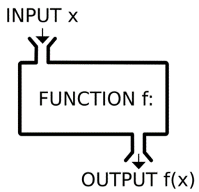

## 패키지 설치

패키지 설치는 `install.packages("package name")`를 이용해서 설치하고, `()`안에 **문자열**로 패키지 이름을 입력하면 된다.

```r
install.packages("readxl")
#여러개를 c()함수에 묶어서 사용
install.packages(c("moonBook", "ztable", "epiDisplay","dplyr",
                   "survival", "ggplot2", "gmodels", "GGally"))
```

## 패키지 적재하기

패키지를 설치하고 현재 작업하는 세션(작업공간)에서 사용하기 위해서는 패키지를 적재(또는 load)해야 한다. `library(package name)` 또는 `require(package name)`함수를 이용해서 패키지를 적재할 수 있다. 두 함수의 차이는 패키지가 설치되지 않은 경우 `library()`함수는 오류를 반환하고 중지하지만 `require()` 함수는 오류를 반환하고 중지하지 않는다. 적재하지 않고 사용하기 위해 `package name::function()` 방식으로 사용하기도 하지만 원활한 작업을 위해서 실행하는 것이 유리한 점이 있다.

- 유의할 점은 패키지 설치와 다르게 패키지를 적재할때는 패키지 이름에 따옴표를 사용하지 않는다. 문자열로 입력하고자 한다면 `character.only=TRUE` 인자를 추가하면 된다.

## 기타 패키지 관련 함수

- `available.packages("package name")`: 패키지가 CRAN에 등록되어 있는지 확인하는 함수
- `update.packages("package name")`: 패키지를 업데이트하는 함수, 패키지명을 제외하고 `update.packages()`만 실행할 경우 모든 패키지를 업데이트 한다.
- `package name::function()` 패키지를 적재하지 않고 특정 패키지의 함수를 사용할 때 이용한다.

## R studio에서 패키지 관리

R studio에서 아래의 그림과 같이 패키지를 설치한다.

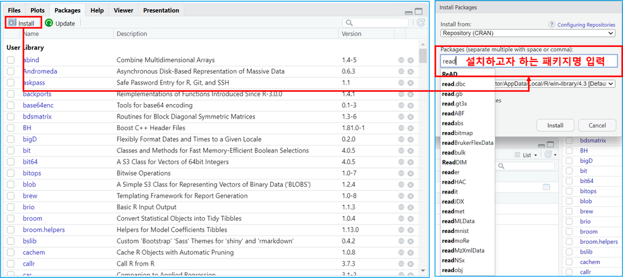

패키지 업데이트는 아래의 그림과 같다.

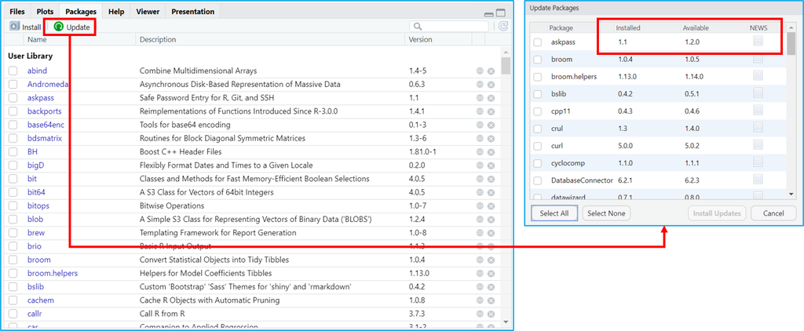

패키지 적재는 체크를 하면 활성화 된다.

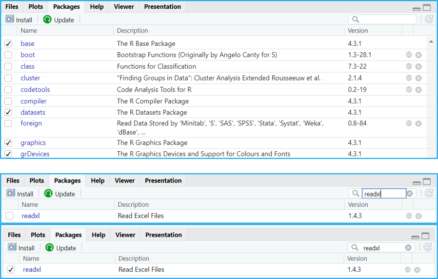

# 2. 데이터 프레임

데이터 프레임(data frame)이란 스프레드시트(spreadsheet) 형식의 구조이며 행과 열로 구성된 2차원 형태이다. 열에는 데이터 속성(자료형 등)이 포함되어 있으며, 행에는 인덱스(index)라는 행을 식별하는 속성이 포함되어 있다. 자료를 분석하기 위한 가장 기본적인 자료 구조이다.

데이터 프레임을 만들기 위한 방법은 자료를 직접입력하거나 외부자료를 불러오기를 통해서 만들 수 있다.

## 데이터 직접입력하기

R의 가장 기본적인 벡터(vector)을 이용해서 데이터 프레임을 만들 수 있다.

벡터란 동일한 자료형의 데이터 값들이 나열되어 있는 데이터 구조이다. 벡터에는 값과 그 값의 위치를 나타내는 인덱스가 포함되어 있다.

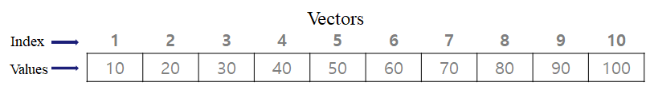

성별을 genders, 악력을 grip_strenth로 변수명을 정하고 값을 저장한다. 이때 성별에 대응하는 악력의 값을 순서대로 입력해야 한다.

```r
genders <- c(0, 1, 1, 0, 0, 1, 1, 1, 0, 0)
grip_strength <- c(35, 18, 10, 42, 26, 15, 20, 9, 29, 37)
print(genders)
```

```
 [1] 0 1 1 0 0 1 1 1 0 0
```

```r
print(grip_strength)
```

```
 [1] 35 18 10 42 26 15 20  9 29 37
```

### 벡터로 데이터 프레임 만들기

여러개의 백터로 하나의 데이터 프레임으로 만들기 위해서 `data.frame()`함수를 이용한다. 백터로 저장된 변수이름을 콤마로 구분해서 나열하면 된다.

```r
df <- data.frame(genders, grip_strength)
print(df)
```

| genders | grip_strength |
| --- | --- |
| 0 | 35 |
| 1 | 18 |
| 1 | 10 |
| 0 | 42 |
| 0 | 26 |
| 1 | 15 |
| 1 | 20 |
| 1 | 9 |
| 0 | 29 |
| 0 | 37 |

데이터 프레임 객체로 저장된 자료는 `View()`함수를 이용해서 데이터를 열어서 확인할 수 있다.

```r
View(df)
```

자료 구조를 `str()`함수를 이용해서 확인한다.

```r
str(df)
```

```
'data.frame':   10 obs. of  2 variables:
 $ genders      : num  0 1 1 0 0 1 1 1 0 0
 $ grip_strength: num  35 18 10 42 26 15 20 9 29 37
```

총 10개의 관측값과 2개의 변수를 가지는 데이터 프레임이다.

## 외부 데이터 이용하기

수집된 자료는 대부분 별도의 시스템, 소프트웨어를 이용해서 수집하기 때문에 R에서 직접 데이터를 입력하는 경우는 드물다. 따라서 외부 데이터를 이용하는 경우가 대부분이며 분석을 위해서 외부에 저장된 데이터를 불러와서 이용한다.

> 깃허브에 `예제데이터_2023.csv`, `예제데이터_2023.xlsx` 파일을 다운받아 해당 프로젝트가 위치한 폴더에 저장해서 이용한다.

### 자료 불러오기(data import, data load)

외부에서 생성된 자료를 불러오기 위해서는 함수를 이용해야 하고, `.csv`, `.txt` 확장자를 가지는 기본적인 텍스트 자료(text file)는 기본 패키지에서 제공하는 read.table(), read.csv()함수를 이용한다. 그 외 엑셀파일(.xls, .xlsx)이나 SPSS(.sav), SAS(.sas7bdat) 등의 외부 데이터는 특정 패키지를 이용해야 한다.

실습을 위해 제공된 csv 파일과 xlsx 파일을 이용해서 불러오는 방법을 설명한다.

#### csv 파일

`예제데이터_2023.csv` 자료는 확장자가 `.csv`로 되어 있으며 CSV(comma-separated values, comma-separated variables)로 열을 쉼표(,)로 구분한 텍스트 데이터 파일이다. 텍스트 데이터 파일의 특징은 열과 행에 속성이 없는 단순한 포멧이다.

`예제데이터_2023.csv`을 메모장(notepad)으로 열어보면 아래의 그림과 같다. 엑셀이 설치된 컴퓨터에서는 엑셀이 기본 프로그램으로 설정되어 엑셀로 파일이 열린다.

[figure not shown]

첫번째 행에는 변수의 한글명(라벨)이, 두번째 행에는 영문 변수명, 세번째 행부터 데이터가 저장되어 있다. 각 열은 쉼표로 구분되어 있다. 밑에서 두번째 행을 자세히 관찰해 보면 쉼표가 연속해서 두번(,,)입력되어 있는데 그 열에 값이 없다(결측)는 것이다.

##### R에서 csv 파일 불러오기

csv 파일은 아래의 코드로 불러올 수 있다. 자료에 변수명(칼럼명)이 있을 경우 `header=TRUE` 인자를 추가하고, 없는 경우 `header=FALSE`를 추가한다. 참고로 `read.csv()` 함수의 `header`의 기본값은 `TRUE`이다(`header=TRUE`를 생략해도 된다).

```r
df <- read.csv("예제데이터_2023.csv", header = T)
head(df) # 앞에서 5개의 자료 확인
```

|  | 성별 | 만나이 | 가구소득 | 걷기.실천 | 주관적.건강수준 | 수축기.혈압 | 이완기.혈압 | 체질량지수 | 당화혈색소 | 혈중크레아티닌 |
| --- | --- | --- | --- | --- | --- | --- | --- | --- | --- | --- |
| 1 | sex | age | ho_incm | pa_walk | subj_health | HE_sbp | HE_dbp | HE_BMI | HE_HbA1c | HE_crea |
| 2 | 1 | 61 | 3 | 0 | 3 | 137.5 | 82.5 | 26.78901657 | 6 | 0.94 |
| 3 | 1 | 57 | 3 | 0 | 2 | 158 | 102 | 25.50664121 | 5.4 | 0.95 |
| 4 | 2 | 39 | 2 | 1 | 4 | 104.5 | 67.5 | 23.07571062 | 5.4 | 0.48 |
| 5 | 1 | 70 | 1 | 0 | 2 | 105.5 | 69 | 18.99383075 | 5.8 | 0.82 |
| 6 | 2 | 72 | 1 | 1 | 3 | 125.5 | 86 | 28.16630609 | 5.7 | 0.63 |

불러올때 첫번째 행을 제외하기 위해 `read.csv()` 함수의 인자로 `skip=1`를 추가한다.

```r
df <- read.csv("예제데이터_2023.csv", skip = 1)
head(df)
```

|  | sex | age | ho_incm | pa_walk | subj_health | HE_sbp | HE_dbp | HE_BMI | HE_HbA1c | HE_crea |
| --- | --- | --- | --- | --- | --- | --- | --- | --- | --- | --- |
| 1 | 1 | 61 | 3 | 0 | 3 | 137.5 | 82.5 | 26.78902 | 6.0 | 0.94 |
| 2 | 1 | 57 | 3 | 0 | 2 | 158.0 | 102.0 | 25.50664 | 5.4 | 0.95 |
| 3 | 2 | 39 | 2 | 1 | 4 | 104.5 | 67.5 | 23.07571 | 5.4 | 0.48 |
| 4 | 1 | 70 | 1 | 0 | 2 | 105.5 | 69.0 | 18.99383 | 5.8 | 0.82 |
| 5 | 2 | 72 | 1 | 1 | 3 | 125.5 | 86.0 | 28.16631 | 5.7 | 0.63 |
| 6 | 2 | 77 | 3 | 1 | 3 | 122.5 | 78.5 | 21.04099 | 5.7 | 0.73 |

```r
str(df) # 자료구조를 확인
```

```
'data.frame':   5222 obs. of  10 variables:
 $ sex        : int  1 1 2 1 2 2 1 1 2 2 ...
 $ age        : int  61 57 39 70 72 77 50 49 70 60 ...
 $ ho_incm    : int  3 3 2 1 1 3 3 2 1 2 ...
 $ pa_walk    : int  0 0 1 0 1 1 1 0 1 0 ...
 $ subj_health: int  3 2 4 2 3 3 3 3 3 3 ...
 $ HE_sbp     : num  138 158 104 106 126 ...
 $ HE_dbp     : num  82.5 102 67.5 69 86 78.5 80.5 74.5 72.5 73 ...
 $ HE_BMI     : num  26.8 25.5 23.1 19 28.2 ...
 $ HE_HbA1c   : num  6 5.4 5.4 5.8 5.7 5.7 5 8.7 5.8 5.5 ...
 $ HE_crea    : num  0.94 0.95 0.48 0.82 0.63 0.73 0.84 0.76 0.97 0.8 ...
```

데이터를 보기 위해서 `View()`함수를 이용할 수 있다.

```r
View(df)
```

R studio의 환경 패널에서 해당 데이터를 클릭해서 확인할 수 있다.

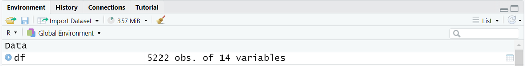

#### 엑셀 파일

엑셀 파일은 readxl, xlsx 패키지를 이용할 수 있으며, 여기서는 readxl 패키지를 이용한다. `예제데이터_2023.xlsx` 자료를 엑셀로 열어서 확인하면 아래의 그림과 같다.

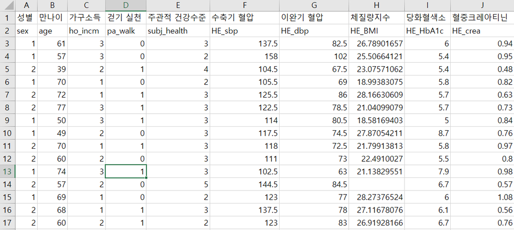

첫번째 행에는 변수의 한글명(라벨)이 입력되어 있고, 두번째행에 영문 변수명, 세번째 행부터 데이터가 입력되어 있다.

엑셀로 저장된 자료는 확장자가 `.xls, .xlsx`로 되어 있으며, 자료를 불러오기 위해서 별도의 패키지가 필요하다. 실습에서는 `readxl` 패키지를 이용한다.

```r
library(readxl)
```

데이터의 첫행은 변수 라벨이므로 제외하기 위해 `skip=1`을 인자로 준다. 첫행이 변수명이고 두번째 행부터 데이터가 입력되어 있다면 생략하면 된다.

```r
df <- read_xlsx("예제데이터_2023.xlsx", skip=1)
head(df)
```

| sex | age | ho_incm | pa_walk | subj_health | HE_sbp | HE_dbp | HE_BMI | HE_HbA1c | HE_crea |
| --- | --- | --- | --- | --- | --- | --- | --- | --- | --- |
| 1 | 61 | 3 | 0 | 3 | 137.5 | 82.5 | 26.78902 | 6.0 | 0.94 |
| 1 | 57 | 3 | 0 | 2 | 158.0 | 102.0 | 25.50664 | 5.4 | 0.95 |
| 2 | 39 | 2 | 1 | 4 | 104.5 | 67.5 | 23.07571 | 5.4 | 0.48 |
| 1 | 70 | 1 | 0 | 2 | 105.5 | 69.0 | 18.99383 | 5.8 | 0.82 |
| 2 | 72 | 1 | 1 | 3 | 125.5 | 86.0 | 28.16631 | 5.7 | 0.63 |
| 2 | 77 | 3 | 1 | 3 | 122.5 | 78.5 | 21.04099 | 5.7 | 0.73 |

```r
str(df)
```

```
tibble [5,222 × 10] (S3: tbl_df/tbl/data.frame)
 $ sex        : num [1:5222] 1 1 2 1 2 2 1 1 2 2 ...
 $ age        : num [1:5222] 61 57 39 70 72 77 50 49 70 60 ...
 $ ho_incm    : num [1:5222] 3 3 2 1 1 3 3 2 1 2 ...
 $ pa_walk    : num [1:5222] 0 0 1 0 1 1 1 0 1 0 ...
 $ subj_health: num [1:5222] 3 2 4 2 3 3 3 3 3 3 ...
 $ HE_sbp     : num [1:5222] 138 158 104 106 126 ...
 $ HE_dbp     : num [1:5222] 82.5 102 67.5 69 86 78.5 80.5 74.5 72.5 73 ...
 $ HE_BMI     : num [1:5222] 26.8 25.5 23.1 19 28.2 ...
 $ HE_HbA1c   : num [1:5222] 6 5.4 5.4 5.8 5.7 5.7 5 8.7 5.8 5.5 ...
 $ HE_crea    : num [1:5222] 0.94 0.95 0.48 0.82 0.63 0.73 0.84 0.76 0.97 0.8 ...
```

### 데이터의 행과 열에 접근하는 방법

dataframe의 자료에서 변수에 접근하는 방법은 자료명 뒤에 `$`를 붙이고 변수명을 작성하면 된다.

```r
head(df$sex) # 출력하면 너무 많기 때문에 head() 함수를 이용해서 앞에 5개 출력
```

```
[1] 1 1 2 1 2 2
```

dataframe은 행렬과 유사하고 열번호와 행번호를 이용해서 접근할 수 있다. 자료명 뒤에 `[]`를 붙여서 이용한다.

```r
df[1]
```

| sex |
| --- |
| 1 |
| 1 |
| 2 |
| 1 |
| 2 |
| 2 |
| 1 |
| 1 |
| 2 |
| 2 |

[output cut: 990 more lines]

```r
df[1:5]
```

| sex | age | ho_incm | pa_walk | subj_health |
| --- | --- | --- | --- | --- |
| 1 | 61 | 3 | 0 | 3 |
| 1 | 57 | 3 | 0 | 2 |
| 2 | 39 | 2 | 1 | 4 |
| 1 | 70 | 1 | 0 | 2 |
| 2 | 72 | 1 | 1 | 3 |
| 2 | 77 | 3 | 1 | 3 |
| 1 | 50 | 3 | 1 | 3 |
| 1 | 49 | 2 | 0 | 3 |
| 2 | 70 | 1 | 1 | 3 |
| 2 | 60 | 2 | 0 | 3 |

[output cut: 990 more lines]

변수명을 문자열로 입력해서 추출할 수 있다.

```r
df[c('sex', 'age')]
```

| sex | age |
| --- | --- |
| 1 | 61 |
| 1 | 57 |
| 2 | 39 |
| 1 | 70 |
| 2 | 72 |
| 2 | 77 |
| 1 | 50 |
| 1 | 49 |
| 2 | 70 |
| 2 | 60 |

[output cut: 990 more lines]

`자료명[행번호, 열번호(변수명)]`로 필요한 데이터에 접근할 수 있다.

```r
df[5, 1]
```

| sex |
| --- |
| 2 |

```r
df[1:5, 1]
```

| sex |
| --- |
| 1 |
| 1 |
| 2 |
| 1 |
| 2 |

대괄호(`[]`)안에 조건을 추가하여 조건에 만족하는 행의 데이터를 추출할 수 있다.

```r
df[df$sex==1, ] # 성별이 남자인 대상자 추출, 성별의 자료형이 숫자이다.
```

| sex | age | ho_incm | pa_walk | subj_health | HE_sbp | HE_dbp | HE_BMI | HE_HbA1c | HE_crea |
| --- | --- | --- | --- | --- | --- | --- | --- | --- | --- |
| 1 | 61 | 3 | 0 | 3 | 137.5 | 82.5 | 26.78902 | 6.0 | 0.94 |
| 1 | 57 | 3 | 0 | 2 | 158.0 | 102.0 | 25.50664 | 5.4 | 0.95 |
| 1 | 70 | 1 | 0 | 2 | 105.5 | 69.0 | 18.99383 | 5.8 | 0.82 |
| 1 | 50 | 3 | 1 | 3 | 114.0 | 80.5 | 18.58169 | 5.0 | 0.84 |
| 1 | 49 | 2 | 0 | 3 | 117.5 | 74.5 | 27.87054 | 8.7 | 0.76 |
| 1 | 74 | 3 | 1 | 3 | 102.5 | 63.0 | 21.13830 | 7.9 | 0.98 |
| 1 | 69 | 1 | 0 | 2 | 123.0 | 77.0 | 28.27377 | 6.0 | 1.08 |
| 1 | 59 | 2 | 1 | 3 | 143.0 | 94.5 | 25.79855 | 6.4 | 0.75 |
| 1 | 55 | 3 | 0 | 3 | 136.0 | 88.0 | 23.87311 | 8.2 | 0.72 |
| 1 | 78 | 1 | 0 | 2 | 117.0 | 70.5 | 24.02893 | 7.0 | 0.76 |

[output cut: 990 more lines]

```r
df[df$age > 65, ] # 나이가 65세 이상인 대상자 추출
```

| sex | age | ho_incm | pa_walk | subj_health | HE_sbp | HE_dbp | HE_BMI | HE_HbA1c | HE_crea |
| --- | --- | --- | --- | --- | --- | --- | --- | --- | --- |
| 1 | 70 | 1 | 0 | 2 | 105.5 | 69.0 | 18.99383 | 5.8 | 0.82 |
| 2 | 72 | 1 | 1 | 3 | 125.5 | 86.0 | 28.16631 | 5.7 | 0.63 |
| 2 | 77 | 3 | 1 | 3 | 122.5 | 78.5 | 21.04099 | 5.7 | 0.73 |
| 2 | 70 | 1 | 1 | 3 | 118.0 | 72.5 | 21.79914 | 5.8 | 0.97 |
| 1 | 74 | 3 | 1 | 3 | 102.5 | 63.0 | 21.13830 | 7.9 | 0.98 |
| 1 | 69 | 1 | 0 | 2 | 123.0 | 77.0 | 28.27377 | 6.0 | 1.08 |
| 2 | 68 | 1 | 1 | 3 | 137.5 | 78.0 | 27.11678 | 6.1 | 0.56 |
| 1 | 78 | 1 | 0 | 2 | 117.0 | 70.5 | 24.02893 | 7.0 | 0.76 |
| 2 | 79 | 1 | 0 | 3 | 117.5 | 66.0 | 20.51869 | 4.6 | 0.73 |
| 1 | 70 | 2 | 1 | 1 | 110.0 | 66.5 | 21.78732 | 5.3 | 0.66 |

[output cut: 990 more lines]

## 데이터 전처리

데이터를 불러와서 저장한다고 분석에 바로 사용할 수 있는 것은 아니다. 데이터를 검토하고 변환하는 과정을 거쳐야 한다. 이 과정에서는 결측과 이상값을 점검하고, 연구에 필요한 변수를 생성(조작적 정의)한다.

### 자료형 변환

성별의 자료형을 변환한다.

```r
df$sex <- as.factor(df$sex) # 성별을 factor 자료형으로 변환
str(df$sex) # 자료구조 확인
```

```
 Factor w/ 2 levels "1","2": 1 1 2 1 2 2 1 1 2 2 ...
```

```r
df$ho_incm <- as.factor(df$ho_incm)
df$pa_walk <- as.factor(df$pa_walk)
df$subj_health <- as.factor(df$subj_health)
```

### 변수의 요약값 확인

`summary()`함수를 이용하면 데이터에 포함된 모든 변수의 요약값을 확인할 수 있다.

```r
summary(df)
```

```
 sex           age        ho_incm     pa_walk     subj_health     HE_sbp
 1:2275   Min.   :30.00   1   :1105   0   :2788   1   : 203   Min.   : 82.0
 2:2947   1st Qu.:46.00   2   :1271   1   :1859   2   :1247   1st Qu.:110.0
          Median :58.00   3   :1372   NA's: 575   3   :2215   Median :120.0
          Mean   :57.57   4   :1443               4   : 824   Mean   :121.4
          3rd Qu.:69.00   NA's:  31               5   : 207   3rd Qu.:131.0
          Max.   :80.00                           9   : 314   Max.   :203.0
                                                  NA's: 212   NA's   :283
     HE_dbp           HE_BMI         HE_HbA1c        HE_crea
 Min.   : 42.00   Min.   :14.75   Min.   : 4.00   Min.   :0.2000
 1st Qu.: 67.50   1st Qu.:21.69   1st Qu.: 5.50   1st Qu.:0.6500
 Median : 73.50   Median :23.97   Median : 5.70   Median :0.7600
 Mean   : 74.41   Mean   :24.21   Mean   : 5.91   Mean   :0.8044
 3rd Qu.: 80.50   3rd Qu.:26.29   3rd Qu.: 6.10   3rd Qu.:0.9100
 Max.   :126.00   Max.   :46.28   Max.   :15.30   Max.   :8.3500
 NA's   :283      NA's   :314     NA's   :363     NA's   :359
```

#### 이산 변수

```r
table(df$sex)
```

```
   1    2
2275 2947
```

```r
table(df$ho_incm)
```

```
   1    2    3    4
1105 1271 1372 1443
```

```r
table(df$pa_walk)
```

```
   0    1
2788 1859
```

```r
table(df$subj_health)
```

```
   1    2    3    4    5    9
 203 1247 2215  824  207  314
```

주관적 건강수준 변수의 항목 값 9는 모름, 무응답이며, 이값을 결측으로 처리해 준다. 특정값을 `NA`로 변경하면 된다.

```r
df$subj_health[df$subj_health=='9'] <- NA
table(df$subj_health)
```

```
   1    2    3    4    5    9
 203 1247 2215  824  207    0
```

factor 자료형에서 처음 선언된 수준(levels)를 기억하기 때문에 이를 제거해주어야 한다.

```r
df$subj_health <- factor(df$subj_health, levels = c('1','2','3','4','5'))
table(df$subj_health)
```

```
   1    2    3    4    5
 203 1247 2215  824  207
```

#### 연속 변수

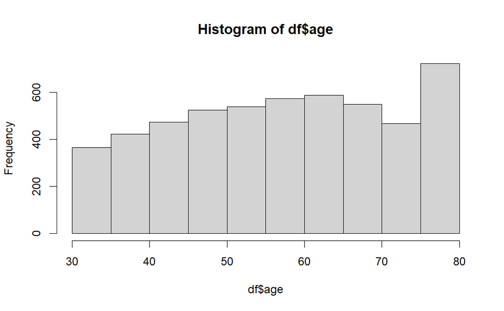

```r
hist(df$age)
```

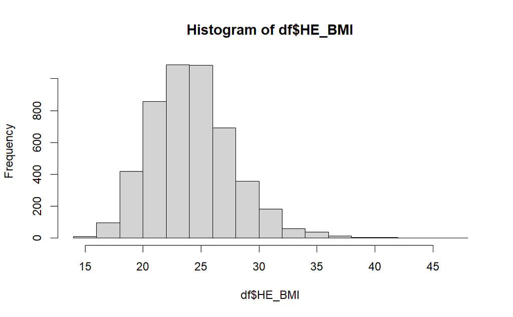

```r
hist(df$HE_BMI)
```

### 조작적 정의

주로 연구에 필요한 변수를 생성하거나 측정값들의 조합으로 새로운 변수를 만드는 과정이다. 검사결과를 이용해서 질환으로 분류하거나, 새로운 지표를 생성하는 조작적 정의를 수행한다.

```r
## 당뇨병 구분
df$DM <- ifelse(df$HE_HbA1c >= 6.5, 2,
                ifelse(df$HE_HbA1c >= 5.8, 1, 0))

## 고혈압 구분
df$HP <- ifelse(df$HE_sbp >= 140 | df$HE_dbp > 90, 2,
                ifelse(df$HE_sbp >= 120 | df$HE_dbp > 80, 1, 0))

# MDRD 연구 계산식
df$eGFR <- ifelse(df$sex =='1',
                  175 * (df$HE_crea^-1.154) * (df$age^-0.203),
                  175 * (df$HE_crea^-1.154) * (df$age^-0.203)*0.742)
```

계산된 지표의 값을 확인한다. 히스토그램의 구간 개수를 지정해서 확인한다. `hist()`함수에 `breaks=`에 개수를 지정하면 된다.

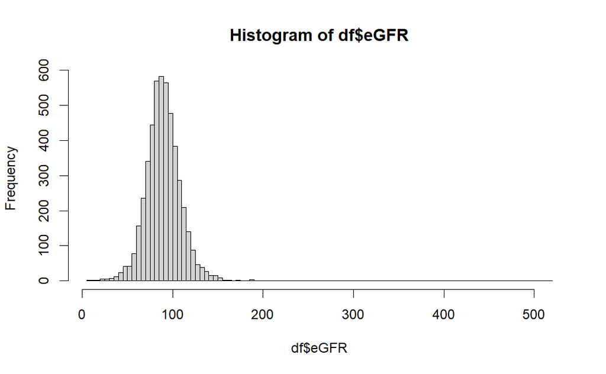

```r
hist(df$eGFR, breaks = 100)
```

값을 추출해서 확인해 본다.

```r
df[!is.na(df$eGFR) & df$eGFR > 200,]
```

| sex | age | ho_incm | pa_walk | subj_health | HE_sbp | HE_dbp | HE_BMI | HE_HbA1c | HE_crea | DM | HP | eGFR |
| --- | --- | --- | --- | --- | --- | --- | --- | --- | --- | --- | --- | --- |
| 1 | 45 | 4 | 1 | 2 | 131.5 | 84 | 27.29118 | 5.2 | 0.2 | 0 | 1 | 517.6632 |

이상값을 처리해 준다.

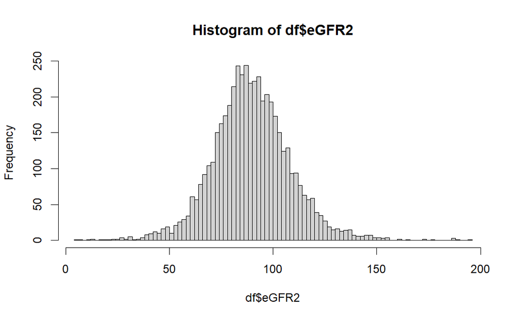

```r
# 이상값(극단값) 제거, 200이상
df$eGFR2 <- ifelse(df$eGFR >= 200, NA, df$eGFR)
hist(df$eGFR2, breaks = 100)
```

분류된 변수의 자료형을 확인하고 변환한다.

```r
df$DM <- as.factor(df$DM)
df$HP <- as.factor(df$HP)
```

### 결측값 처리

결측값이 포함된 자료를 이용해서 분석을 실시하게 되면 원하는 결과를 얻지 못하고 잘못된 결과를 도출할 가능성이 있다.

분석에 사용되는 자료를 정제가 완료된 자료이어야 한다.

결측값을 처리하기 위한 방법은 크게 두가지이다.

1. 제거하기
2. 보간하기(imputation)

제거하기,삭제하는 방법은 대부분의 경우에서 좋은 방법이다.

보간은 결측 데이터가 있을 때 대체할 수 있는 값으로 대체하는 과정을 말한다. 평균으로 대체하거나 예측 모형을 만들어 대체하는 방법을 이용한다.

#### 결측값 확인

결측값을 확인하는 방법은 `is.na()`함수를 이용하거나 `complete.cases()` 함수를 이용하면 된다.

`is.na()`함수는 결측이면 TRUE를 반환한다. 결측이 아닐 경우를 확인하고자 한다면 반대를 의미하는 연산자인 느낌표를 붙여서 `!is.na()` 사용한다. 각 셀에 대해서 모든 체크하기 때문에 모든 값을 확인하기 힘들다. `sum()`, `colSums()`함수를 이용해서 결측값이 있는 셀의 수를 확인한다.

```r
sum(is.na(df))
```

```
[1] 4099
```

```r
sum(!is.na(df))
```

```
[1] 69009
```

```r
colSums(is.na(df)) # 칼럼별 합계
```

```
        sex         age     ho_incm     pa_walk subj_health      HE_sbp
          0           0          31         575         526         283
     HE_dbp      HE_BMI    HE_HbA1c     HE_crea          DM          HP
        283         314         363         359         363         283
       eGFR       eGFR2
        359         360
```

`complete.cases()`는 모든 변수에 대해서 결측이 없는 행인지 확인해 준다.

총 5,222건의 케이스에서 결측이 없는 케이스는 4,399건 이다.

```r
sum(complete.cases(df))
```

```
[1] 4399
```

결측이 없는 케이스만 저장한다.

```r
df_complete <- df[complete.cases(df), ]
head(df_complete)
```

| sex | age | ho_incm | pa_walk | subj_health | HE_sbp | HE_dbp | HE_BMI | HE_HbA1c | HE_crea | DM | HP | eGFR | eGFR2 |
| --- | --- | --- | --- | --- | --- | --- | --- | --- | --- | --- | --- | --- | --- |
| 1 | 61 | 3 | 0 | 3 | 137.5 | 82.5 | 26.78902 | 6.0 | 0.94 | 1 | 1 | 81.58805 | 81.58805 |
| 1 | 57 | 3 | 0 | 2 | 158.0 | 102.0 | 25.50664 | 5.4 | 0.95 | 0 | 2 | 81.71512 | 81.71512 |
| 2 | 39 | 2 | 1 | 4 | 104.5 | 67.5 | 23.07571 | 5.4 | 0.48 | 0 | 0 | 143.98042 | 143.98042 |
| 1 | 70 | 1 | 0 | 2 | 105.5 | 69.0 | 18.99383 | 5.8 | 0.82 | 1 | 0 | 92.88422 | 92.88422 |
| 2 | 72 | 1 | 1 | 3 | 125.5 | 86.0 | 28.16631 | 5.7 | 0.63 | 0 | 1 | 92.88904 | 92.88904 |
| 2 | 77 | 3 | 1 | 3 | 122.5 | 78.5 | 21.04099 | 5.7 | 0.73 | 0 | 1 | 77.30539 | 77.30539 |

#### 변수 추출

분석에 사용하는 변수만 추출하여 저장한다.

```r
df_finish <- df_complete[, c('sex','age','ho_incm','pa_walk','subj_health',
                             'HE_BMI','DM','HP','eGFR2')]
head(df_finish)
```

| sex | age | ho_incm | pa_walk | subj_health | HE_BMI | DM | HP | eGFR2 |
| --- | --- | --- | --- | --- | --- | --- | --- | --- |
| 1 | 61 | 3 | 0 | 3 | 26.78902 | 1 | 1 | 81.58805 |
| 1 | 57 | 3 | 0 | 2 | 25.50664 | 0 | 2 | 81.71512 |
| 2 | 39 | 2 | 1 | 4 | 23.07571 | 0 | 0 | 143.98042 |
| 1 | 70 | 1 | 0 | 2 | 18.99383 | 1 | 0 | 92.88422 |
| 2 | 72 | 1 | 1 | 3 | 28.16631 | 0 | 1 | 92.88904 |
| 2 | 77 | 3 | 1 | 3 | 21.04099 | 0 | 1 | 77.30539 |

`dplyr` 패키지의 `select()` 함수를 이용해서 변수를 추출할 수 있다.

```r
library(dplyr)
df_finish <- select(df_complete, c('sex', 'age'))
head(df_finish)
```

| sex | age |
| --- | --- |
| 1 | 61 |
| 1 | 57 |
| 2 | 39 |
| 1 | 70 |
| 2 | 72 |
| 2 | 77 |

추출하는 변수가 많고 제외하는 변수가 적을 경우 변수를 제외하는 것이 효율적일 수도 있다. `-c()`빼기를 붙여 변수를 문자열로 묶어서 사용하면 된다.

```r
df_finish <- select(df_complete, -c('HE_sbp', 'HE_dbp', 'HE_HbA1c',
                                    'HE_crea','eGFR'))
head(df_finish)
```

| sex | age | ho_incm | pa_walk | subj_health | HE_BMI | DM | HP | eGFR2 |
| --- | --- | --- | --- | --- | --- | --- | --- | --- |
| 1 | 61 | 3 | 0 | 3 | 26.78902 | 1 | 1 | 81.58805 |
| 1 | 57 | 3 | 0 | 2 | 25.50664 | 0 | 2 | 81.71512 |
| 2 | 39 | 2 | 1 | 4 | 23.07571 | 0 | 0 | 143.98042 |
| 1 | 70 | 1 | 0 | 2 | 18.99383 | 1 | 0 | 92.88422 |
| 2 | 72 | 1 | 1 | 3 | 28.16631 | 0 | 1 | 92.88904 |
| 2 | 77 | 3 | 1 | 3 | 21.04099 | 0 | 1 | 77.30539 |

파이프 연산자 `%>%`를 이용할 수도 있다.

```r
df_finish <- df_complete %>% select(-c('HE_sbp', 'HE_dbp', 'HE_HbA1c',
                                    'HE_crea','eGFR'))
head(df_finish)
```

| sex | age | ho_incm | pa_walk | subj_health | HE_BMI | DM | HP | eGFR2 |
| --- | --- | --- | --- | --- | --- | --- | --- | --- |
| 1 | 61 | 3 | 0 | 3 | 26.78902 | 1 | 1 | 81.58805 |
| 1 | 57 | 3 | 0 | 2 | 25.50664 | 0 | 2 | 81.71512 |
| 2 | 39 | 2 | 1 | 4 | 23.07571 | 0 | 0 | 143.98042 |
| 1 | 70 | 1 | 0 | 2 | 18.99383 | 1 | 0 | 92.88422 |
| 2 | 72 | 1 | 1 | 3 | 28.16631 | 0 | 1 | 92.88904 |
| 2 | 77 | 3 | 1 | 3 | 21.04099 | 0 | 1 | 77.30539 |

# 기초 분석

기초분석은 변수 하나하나를 이용한 분포를 확인하는 과정과 탐색적 자료 분석을 포함하는 개념이지만 여기서는 두 변수 간의 관계를 알아보는 기초 분석 방법을 설명한다.

통계 분석 방법을 어떻게 선택하는가?

1. 변수의 종류: 특히 척도를 중심으로
- 반응(종속) 변수 vs 설명(독립) 변수
- 이산 변수 vs 연속 변수
- 질적(범주) 변수 vs 양적 변수
2. 자료의 크기와 분포
- 모수적 방법 vs 비모수적 방법
3. 변수 간의 독립성
- 독립 표본 vs 대응 표본
4. 변수의 수
- 반응 변수의 수: 단변량(univariate), 다변량(multivariate)
- 설명 변수의 수: 단변수(univariable, simple), 다변수(multivariable, multiple)

## 교차 분석

두개 이상의 변수가 모두 범주형 변수이고 서로 독립인지 검정하는 방법이다. 기대빈도는 두 변수가 서로 상관이 없고 독립적이라고 기대하는 것을 의미하며, 관찰빈도와의 차이를 통해 검정하는 방법이다.

- 귀무가설: 두 변수는 연관성이 없다(독립O)
- 대립가설: 두 변수는 연관성이 있다(독립X, 상관)

교차표를 만드는 것으로 시작한다.

```r
table(df_finish[, c('sex', 'pa_walk')])
```

```
   pa_walk
sex    0    1
  1 1192  736
  2 1443 1028
```

```r
prop.table(table(df_finish[, c('sex', 'pa_walk')]))
```

```
   pa_walk
sex         0         1
  1 0.2709707 0.1673108
  2 0.3280291 0.2336895
```

교차표를 tb1이라는 이름으로 저장하고 `chisq.test()`에 주면 카이제곱검정 결과를 확인할 수 있다. `correct=FALSE`를 인자로 설정해야 한다.

```r
tb1 <- table(df_finish[, c('sex', 'pa_walk')])
chisq.test(tb1, correct=FALSE)
```

```
    Pearson's Chi-squared test

data:  tb1
X-squared = 5.2993, df = 1, p-value = 0.02133
```

`gmodels` 패키지를 이용해서 교차분석을 수행할 수 있으며, 패키지를 이용할 경우 교차표를 별도로 생성하지 않아도 된다.

```r
library(gmodels)
CrossTable(df_finish$sex, df_finish$pa_walk, chisq = TRUE)
```

```
   Cell Contents
|-------------------------|
|                       N |
| Chi-square contribution |
|           N / Row Total |
|           N / Col Total |
|         N / Table Total |
|-------------------------|


Total Observations in Table:  4399


              | df_finish$pa_walk
df_finish$sex |         0 |         1 | Row Total |
--------------|-----------|-----------|-----------|
            1 |      1192 |       736 |      1928 |
              |     1.194 |     1.783 |           |
              |     0.618 |     0.382 |     0.438 |
              |     0.452 |     0.417 |           |
              |     0.271 |     0.167 |           |
--------------|-----------|-----------|-----------|
            2 |      1443 |      1028 |      2471 |
              |     0.931 |     1.391 |           |
              |     0.584 |     0.416 |     0.562 |
              |     0.548 |     0.583 |           |
              |     0.328 |     0.234 |           |
--------------|-----------|-----------|-----------|
 Column Total |      2635 |      1764 |      4399 |
              |     0.599 |     0.401 |           |
--------------|-----------|-----------|-----------|


Statistics for All Table Factors


Pearson's Chi-squared test
------------------------------------------------------------
Chi^2 =  5.299273     d.f. =  1     p =  0.02133433

Pearson's Chi-squared test with Yates' continuity correction
------------------------------------------------------------
Chi^2 =  5.157506     d.f. =  1     p =  0.02314612
```

일반 카이제곱검정과 Yates’s continuity correction이 적용된 검정의 결과를 보여준다. 예이츠(yates’s) 연속성 보정 결과는 현재 쓰이지 않는다.

## 상관분석

두개의 연속 변수가 서로 선형적 관계를 갖고 있는 지를 분석하는 방법이다.

두 변수간의 관계 강도를 상관관계(correlation)라고 하며 상관분석에서 상관관계의 정도를 나타내는 단위로 모상관계수 rho $\rho$를 사용하면 표본 상관 계수로 r을 사용한다.

- 모 상관계수가 0이다.
- 모 상관계수가 0이 아니다.

상관계수가 0이라는 것은 “상관이 없다”로 해석하지만 엄밀히 말해서 선형관계가 아니다로 해석하는것이 올바르다.

```r
cor(df_finish$HE_BMI, df_finish$eGFR2)
```

```
[1] -0.04295641
```

상관계수의 해석은 다음과 같다. 절대적인 의미는 아니다. - r이 -1.0과 -0.7 사이이면, 강한 음적 선형관계 - r이 -0.7과 -0.3 사이이면, 뚜렷한 음적 선형관계 - r이 -0.3과 -0.1 사이이면, 약한 음적 선형관계 - r이 -0.1과 +0.1 사이이면, 거의 무시될 수 있는 선형관계 - r이 +0.1과 +0.3 사이이면, 약한 양적 선형관계 - r이 +0.3과 +0.7 사이이면, 뚜렷한 양적 선형관계 - r이 +0.7과 +1.0 사이이면, 강한 양적 선형관계

산점도를 이용해서 시각화해서 확인한다.

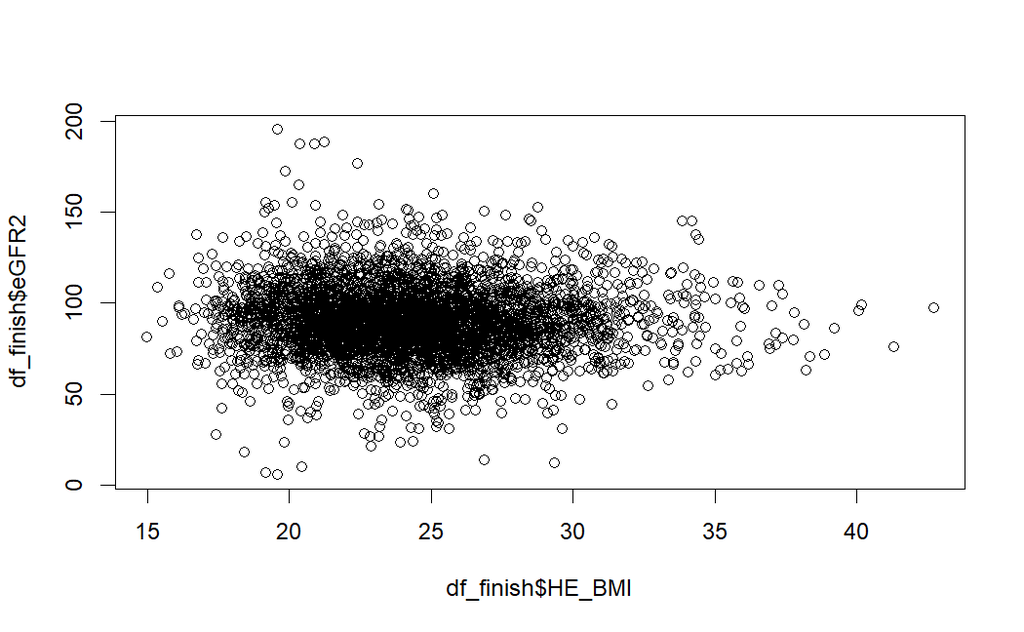

```r
plot(df_finish$HE_BMI, df_finish$eGFR2)
```

한번에 많은 변수로 그래프를 그릴 수 있다.

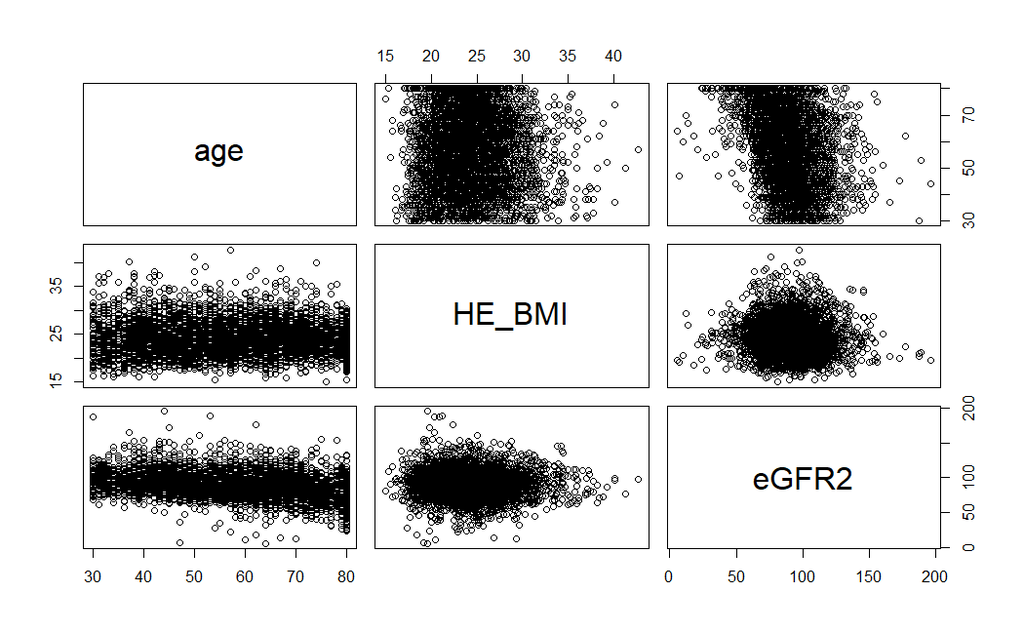

```r
pairs(df_finish[, c("age","HE_BMI","eGFR2")])
```

패키지에서 제공하는 유용한 기능을 이용해서 쉽게 확인할 수 있다.

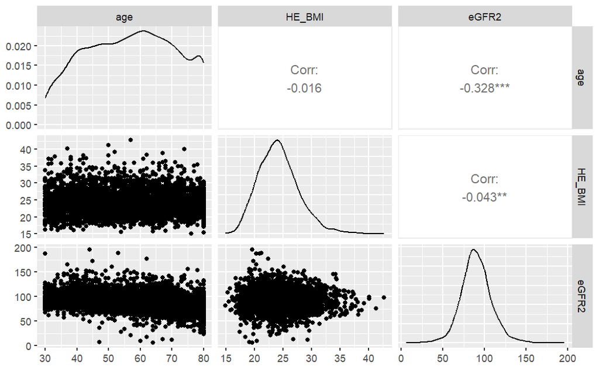

```r
library("ggplot2")
library("GGally")
ggpairs(df_finish[, c("age","HE_BMI","eGFR2")])
```

## 평균비교

평균 비교의 분석 방법은 아래의 그림과 같이 결정된다.

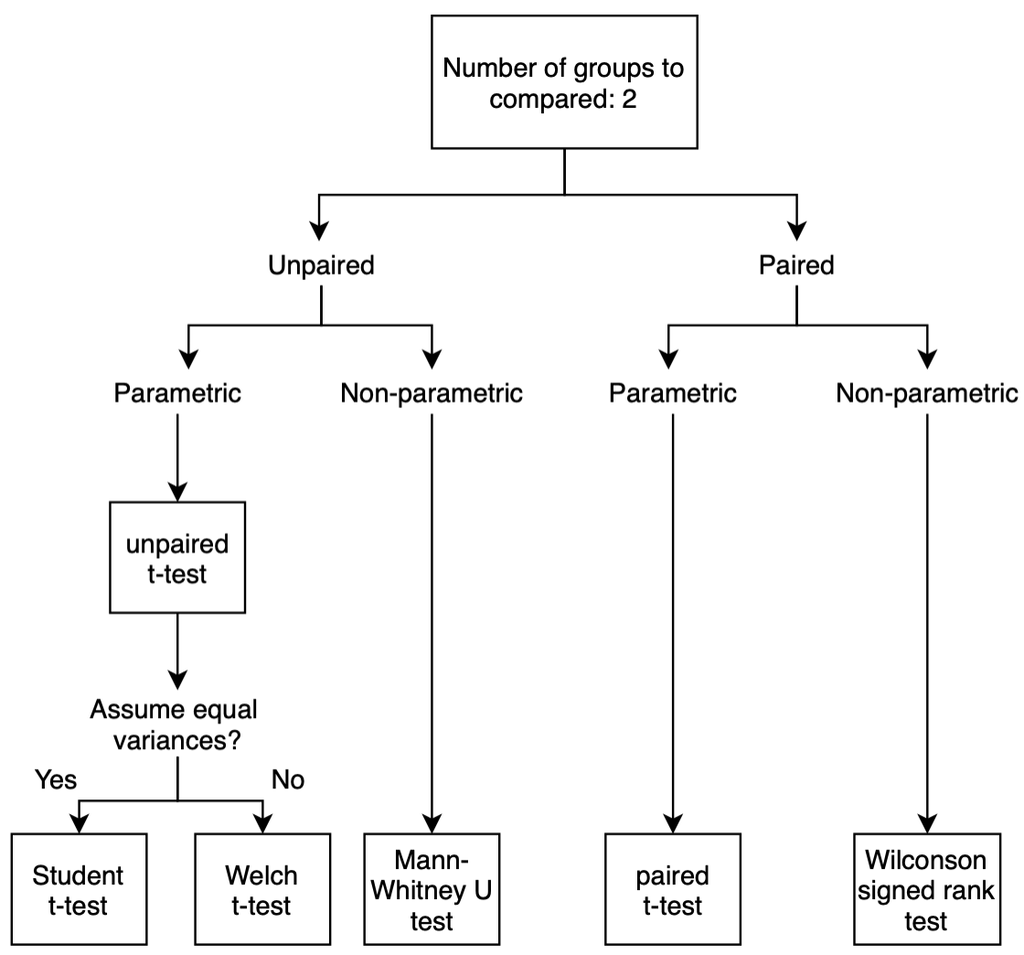

모수적, 비모수적 분석 방법의 결정은 척도와 정규성 검정, 샘플 수를 이용해서 판단한다.

- 귀무가설: 두 모집단의 평균은 같다. 두 집단 간의 평균 차이는 없다.
- 대립가설: 두 모집단의 평균은 같지 않다. 두 집단 간의 평균 차이는 있다.

독립표본 T 검정은 먼저 등분산 검정을 실시한다.

```r
var.test(df_finish$eGFR2 ~ df_finish$sex) # 등분산검정
```

```
    F test to compare two variances

data:  df_finish$eGFR2 by df_finish$sex
F = 0.85763, num df = 1927, denom df = 2470, p-value = 0.0003738
alternative hypothesis: true ratio of variances is not equal to 1
95 percent confidence interval:
 0.7884936 0.9332398
sample estimates:
ratio of variances
         0.8576284
```

```r
# var.test(HE_crea ~ sex, data=df_finish)
```

등분산 검정을 확인하는 F-test는 두 분산의 비율이 1에서 얼마나 벗어 났는가를 이용한다.

```r
sd_group1 <- sd(df_finish[df_finish$sex == '1', ]$eGFR2)
sd_group2 <- sd(df_finish[df_finish$sex == '2', ]$eGFR2)
cat(sd_group1, sd_group2, sd_group1/sd_group2)
```

```
17.60458 19.00973 0.9260823
```

’t.test()’함수를 이용해서 t-test를 수행한다. 성별에 따라서 GFR은 등분산을 만족하지 못하므로 `var.equal=FALSE`로 설정한다.

```r
t.test(eGFR2 ~ sex, data=df_finish, paired=FALSE, var.equal = FALSE)
```

```
    Welch Two Sample t-test

data:  eGFR2 by sex
t = -10.785, df = 4270.6, p-value < 2.2e-16
alternative hypothesis: true difference in means between group 1 and group 2 is not equal to 0
95 percent confidence interval:
 -7.061868 -4.889344
sample estimates:
mean in group 1 mean in group 2
       86.55496        92.53057
```

또다른 예로 성별에 따른 나이의 평균 차이검정을 실시한다.

먼저 등분산 검정을 실시한다.

```r
var.test(df_finish$age ~ df_finish$sex) # 등분산검정
```

```
    F test to compare two variances

data:  df_finish$age by df_finish$sex
F = 1.0348, num df = 1927, denom df = 2470, p-value = 0.4252
alternative hypothesis: true ratio of variances is not equal to 1
95 percent confidence interval:
 0.9513602 1.1260044
sample estimates:
ratio of variances
          1.034775
```

성별에 따라서 나이는 등분산을 만족하므로 `var.equal=TRUE`로 설정한다.

```r
res_ttest <- t.test(age ~ sex, data=df_finish, paired=FALSE, var.equal = TRUE)
cat("t-value: ", res_ttest$statistic,
    ", p-value: ", res_ttest$p.value)
```

```
t-value:  -0.07114287 , p-value:  0.9432873
```

## 분산분석

2개 이상 다수의 집단을 서로 비교하고자 할 때 집단 내의 분산, 총평균 그리고 각 집단의 평균의 차이에 의해 생긴 집단 간 분산의 비교를 통해 만들어진 F분포를 이용하여 가설검정을 하는 방법이다(wiki).

One-way ANOVA는 하나의 설명변수, Two-way ANOVA는 두개의 독립변수일때의 방법이다.

- 귀무가설: 평균 차이는 없다.
- 대립가설: 평균이 서로 다르다. 평균 차이는 있다.

```r
res_anova <- aov(df_finish$eGFR2 ~ df_finish$ho_incm)
res_anova
```

```
Call:
   aov(formula = df_finish$eGFR2 ~ df_finish$ho_incm)

Terms:
                df_finish$ho_incm Residuals
Sum of Squares            24294.3 1504178.9
Deg. of Freedom                 3      4395

Residual standard error: 18.49994
Estimated effects may be unbalanced
```

`summary()`함수를 이용해서 요약 통계량을 산출

```r
summary(res_anova)
```

```
                    Df  Sum Sq Mean Sq F value   Pr(>F)
df_finish$ho_incm    3   24294    8098   23.66 3.46e-15 ***
Residuals         4395 1504179     342
---
Signif. codes:  0 ‘***’ 0.001 ‘**’ 0.01 ‘*’ 0.05 ‘.’ 0.1 ‘ ’ 1
```

### 사후 분석

분산분석은 집단간 평균 차이 여부를 알려주지만 어떤 차이인지 알려주지 않는다. 이를 확인하기 위한 방법이 사후 분석이며 tukey, duncan, bonferroni 등을 주로 이용한다.

```r
res_tukey <- TukeyHSD(res_anova)
res_tukey
```

```
  Tukey multiple comparisons of means
    95% family-wise confidence level

Fit: aov(formula = df_finish$eGFR2 ~ df_finish$ho_incm)

$`df_finish$ho_incm`
          diff        lwr      upr     p adj
2-1 5.11609064  2.9394175 7.292764 0.0000001
3-1 6.08815046  3.9682478 8.208053 0.0000000
4-1 6.15617089  4.0594833 8.252858 0.0000000
3-2 0.97205982 -1.0292433 2.973363 0.5960510
4-2 1.04008025 -0.9366154 3.016776 0.5295792
4-3 0.06802043 -1.8459825 1.982023 0.9997272
```

분석 결과를 저장해서 `plot()`함수로 그래프를 그려본다.

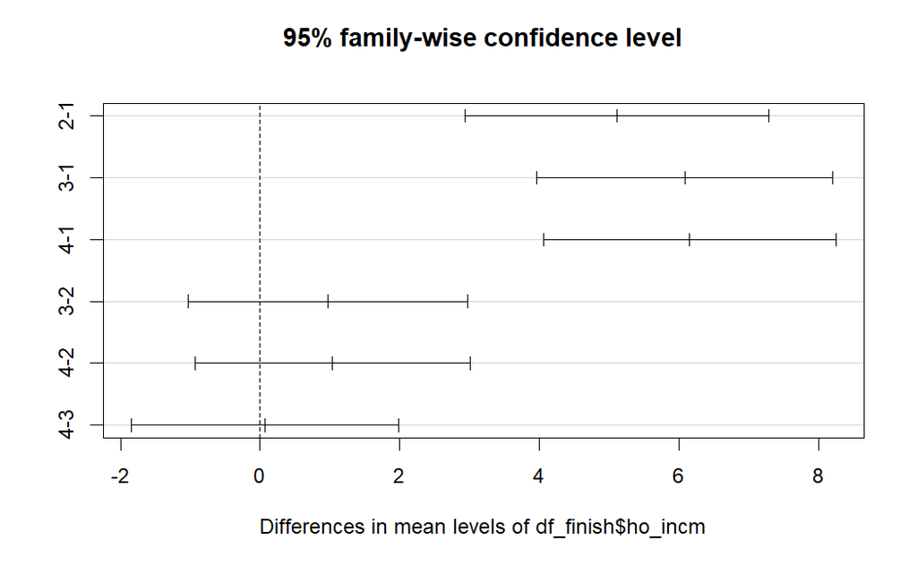

```r
plot(res_tukey)
```

## moomBook 패키지를 이용

```r
library("moonBook")
library("ztable")
```

`mytable()` 함수에서 칼럼을 지정하지 않으면 전체 자료에서 빈도를 계산해 주고 결측값을 확인할 수 있다.

```r
print(mytable(~ sex + HE_BMI, data=df_finish))
```

```
          Descriptive Statistics
———————————————————————————————————————————
       Mean ± SD or %    N   Missing (%)
———————————————————————————————————————————
  sex                    4399  0  ( 0.0%)
    - 1   1928  (43.8%)
    - 2   2471  (56.2%)
   HE_BMI    24.3 ± 3.6  4399  0  ( 0.0%)
———————————————————————————————————————————
```

결측을 제거하기 전의 자료를 이용해서 확인한다.

```r
print(mytable(~ sex + HE_BMI, data=df))
```

```
           Descriptive Statistics
—————————————————————————————————————————————
       Mean ± SD or %    N    Missing (%)
—————————————————————————————————————————————
  sex                    5222    0  ( 0.0%)
    - 1   2275  (43.6%)
    - 2   2947  (56.4%)
   HE_BMI    24.2 ± 3.6  4908  314  ( 6.0%)
—————————————————————————————————————————————
```

자료의 전체 변수의 기술통계량과 결측 확인한다. 최종 모형에 이용되는 자료는 전처리가 완료된 깨끗한 자료여야 한다.

```r
print(mytable(~ ., data=df_finish))
```

```
             Descriptive Statistics
————————————————————————————————————————————————
            Mean ± SD or %    N   Missing (%)
————————————————————————————————————————————————
  sex                         4399  0  ( 0.0%)
    - 1        1928  (43.8%)
    - 2        2471  (56.2%)
   age           56.9 ± 14.0  4399  0  ( 0.0%)
  ho_incm                     4399  0  ( 0.0%)
    - 1         865  (19.7%)
    - 2        1064  (24.2%)
    - 3        1202  (27.3%)
    - 4        1268  (28.8%)
  pa_walk                     4399  0  ( 0.0%)
    - 0        2635  (59.9%)
    - 1        1764  (40.1%)
  subj_health                 4399  0  ( 0.0%)
    - 1          194  (4.4%)
    - 2        1195  (27.2%)
    - 3        2107  (47.9%)
    - 4         730  (16.6%)
    - 5          173  (3.9%)
   HE_BMI         24.3 ± 3.6  4399  0  ( 0.0%)
  DM                          4399  0  ( 0.0%)
    - 0        2328  (52.9%)
    - 1        1450  (33.0%)
    - 2         621  (14.1%)
  HP                          4399  0  ( 0.0%)
    - 0        2122  (48.2%)
    - 1        1634  (37.1%)
    - 2         643  (14.6%)
   eGFR2         89.9 ± 18.6  4399  0  ( 0.0%)
————————————————————————————————————————————————
```

성별을 칼럼(집단)변수로 설정하면 집단간 비교 결과로된 기술통계량 표를 구할 수 있다. `~` 기호 앞에 칼럼 변수를 추가한다. 콘솔 창에 출력되는 결과를 보면 유의확률(p)이 0.05보다 작은 변수는 붉은 색으로 표시된다.

```r
print(mytable(sex ~ ., data=df_finish))
```

```
      Descriptive Statistics by 'sex'
————————————————————————————————————————————
                  1            2         p
               (N=1928)     (N=2471)
————————————————————————————————————————————
 age         56.9 ± 14.1  56.9 ± 13.9  0.943
 ho_incm                               0.000
   - 1       324 (16.8%)  541 (21.9%)
   - 2       453 (23.5%)  611 (24.7%)
   - 3       560 (29.0%)  642 (26.0%)
   - 4       591 (30.7%)  677 (27.4%)
 pa_walk                               0.023
   - 0       1192 (61.8%) 1443 (58.4%)
   - 1       736 (38.2%)  1028 (41.6%)
 subj_health                           0.000
   - 1       104 ( 5.4%)   90 ( 3.6%)
   - 2       598 (31.0%)  597 (24.2%)
   - 3       911 (47.3%)  1196 (48.4%)
   - 4       268 (13.9%)  462 (18.7%)
   - 5        47 ( 2.4%)  126 ( 5.1%)
 HE_BMI      24.7 ±  3.3  23.9 ±  3.7  0.000
 DM                                    0.000
   - 0       996 (51.7%)  1332 (53.9%)
   - 1       613 (31.8%)  837 (33.9%)
   - 2       319 (16.5%)  302 (12.2%)
 HP                                    0.000
   - 0       775 (40.2%)  1347 (54.5%)
   - 1       830 (43.0%)  804 (32.5%)
   - 2       323 (16.8%)  320 (13.0%)
 eGFR2       86.6 ± 17.6  92.5 ± 19.0  0.000
————————————————————————————————————————————
```

`ztable` 패키지를 이용해서 Viewer창에 표시하기 위해서 `type="viewer"`을 추가한다.

```r
print(ztable(mytable(sex ~ ., data=df_finish)), type="viewer")
```

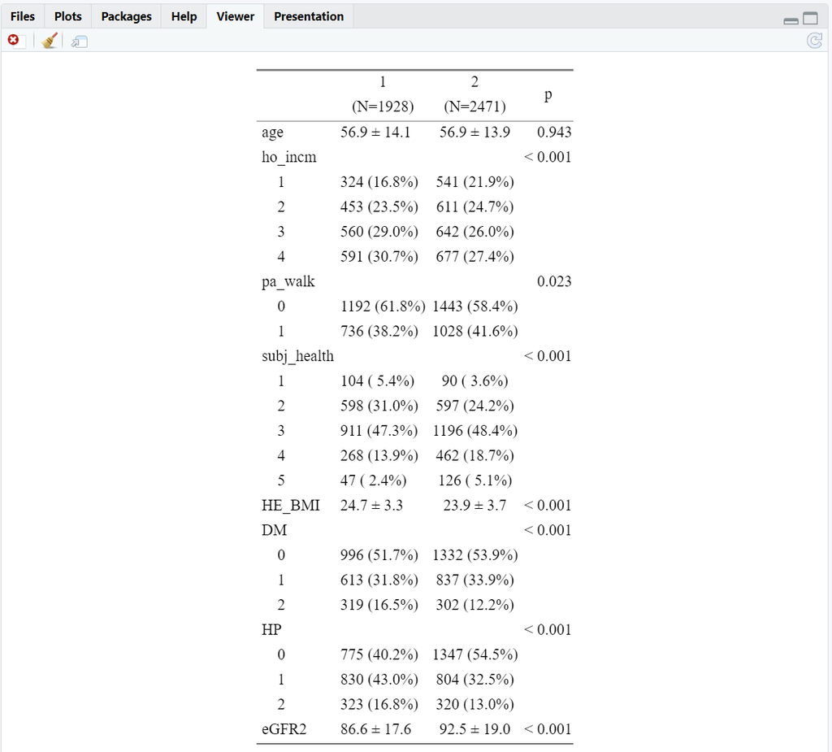

데이터의 종류에 따라서 분석 방법을 결정한다.

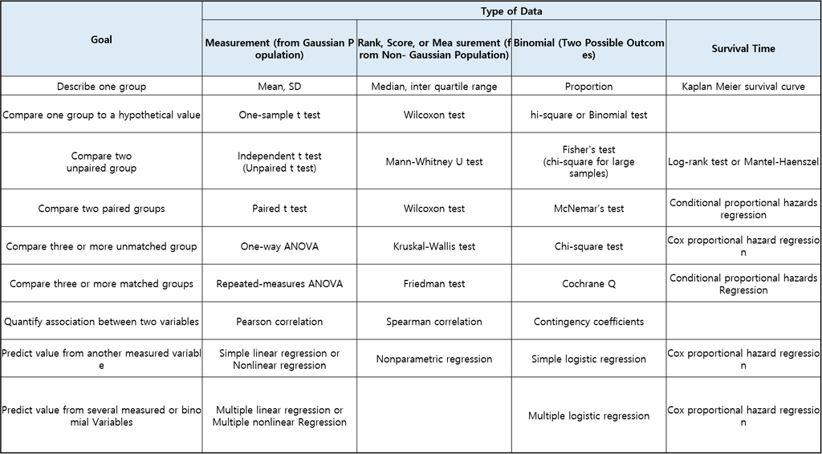

5가지 질문을 가지고 아래의 그림과 같이 분석 방법을 결정한다.

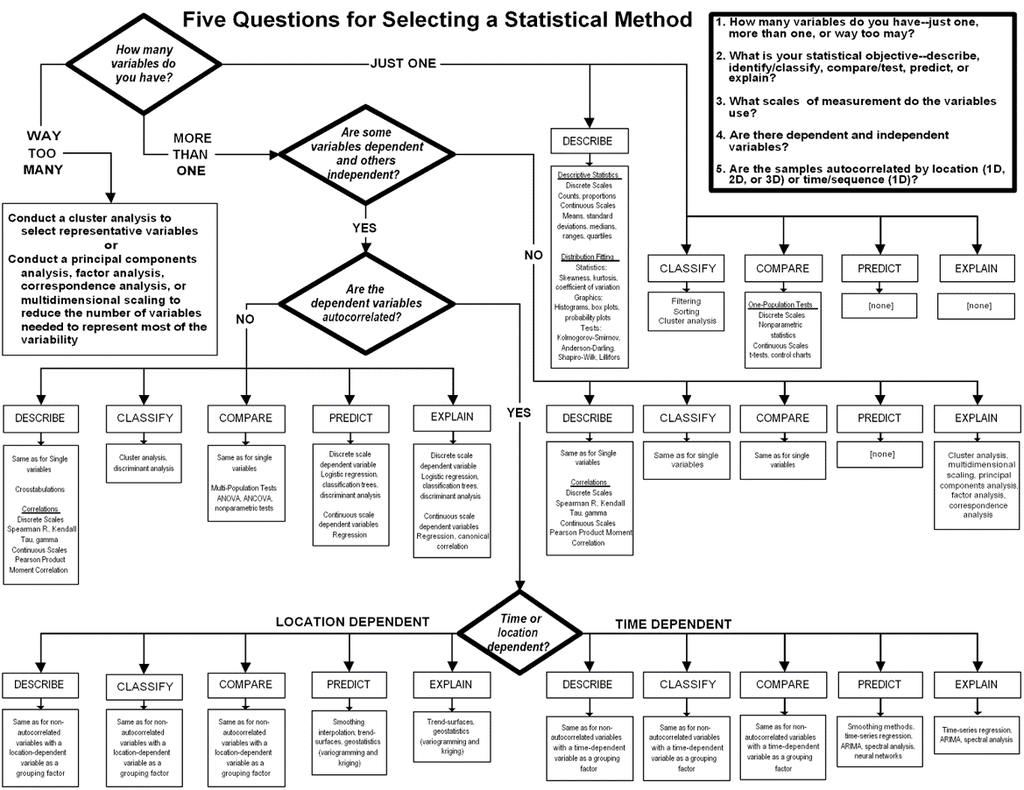